# Examen 3

Mayela Fosado

2023-01-12

# Segunda Parte

Librería que se va a utilizar.

```r
library(deSolve)
```

### Considera un modelo SIR sin demografía en donde la población se conserva.

## a) Escribe y resuelve las ecuaciones diferenciales para valores de R0 = β/γ = 1.75, 2, 2.5

## b) Considera la condición inicial (S = 10^6, I = 1, R = 0)

#### Ecuaciones:

$$\dot S=-\beta SI$$
$$\dot I=\beta SI - \gamma I$$
$$\dot R=\gamma I$$
$$R_0 = \beta / \gamma$$

#### Resolución de las ecuaciones:

No me salió el cálculo de la tasa de infección, entonces hice un ciclo for para ver qué valores me arrojaban los tres valores de $R_0$ (1.75, 2, 2.5).

```r
beta <- 15
gama <- 10

for (i in 5:35) {
  gama <- gama - .1
  beta <- beta + .1
  R0 <- beta/gama
  print(c(gama, beta, R0))
}
```

```
## [1]  9.900000 15.100000  1.525253
## [1]  9.80000 15.20000  1.55102
## [1]  9.70000 15.30000  1.57732
## [1]  9.600000 15.400000  1.604167
## [1]  9.500000 15.500000  1.631579
## [1]  9.400000 15.600000  1.659574
## [1]  9.300000 15.700000  1.688172
## [1]  9.200000 15.800000  1.717391
## [1]  9.100000 15.900000  1.747253
## [1]  9.000000 16.000000  1.777778
## [1]  8.900000 16.100000  1.808989
## [1]  8.800000 16.200000  1.840909
## [1]  8.700000 16.300000  1.873563
## [1]  8.600000 16.400000  1.906977
## [1]  8.500000 16.500000  1.941176
```

[output cut: 16 more lines]

$R_0 1 = 1.75$

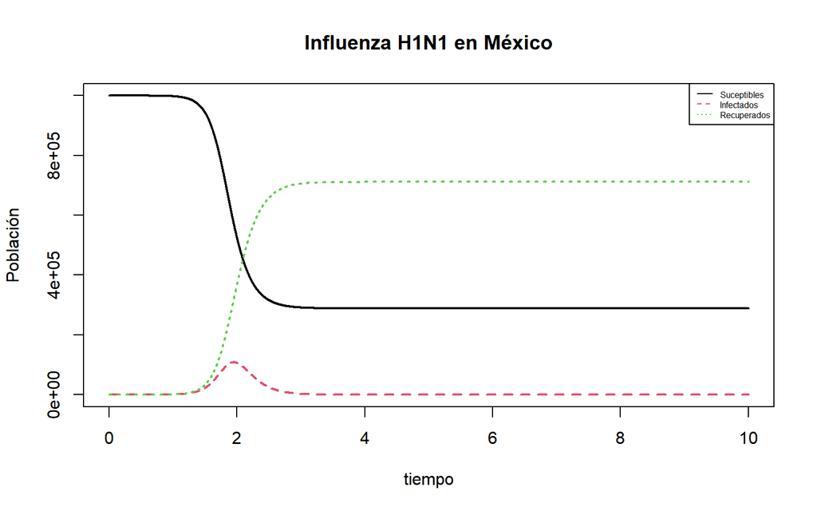

```r
### Funcion SIR:

SIR <- function(t, state, parameters) {
  with(as.list(c(state, parameters)), {

    dS <- -beta*S*I/(S+I+R)
    dI <- beta*S*I/(S+I+R) -gama*I
    dR <- gama*I

    list(c(dS, dI, dR))
  })
}

###  Condiciones iniciales:

pars_1 <- c(beta = 15.900000, gama = 9.100000)
condiciones_iniciales <- c(S = 10^6, I = 1, R = 0)
tiempo_1 <- seq(0, 10, by = 0.0001)
out_1 <- ode(condiciones_iniciales, tiempo_1, SIR, pars_1)


### Grafica:

matplot(out_1[ , 1], out_1[ , 2:4], type = "l", xlab = "tiempo", ylab = "Población", main = "Influenza H1N1 en México", lwd = 2)
legend("topright", c("Suceptibles", "Infectados","Recuperados"), col = 1:4, lty = 1:4, cex = 0.5)
```

$R_0 2 = 2$

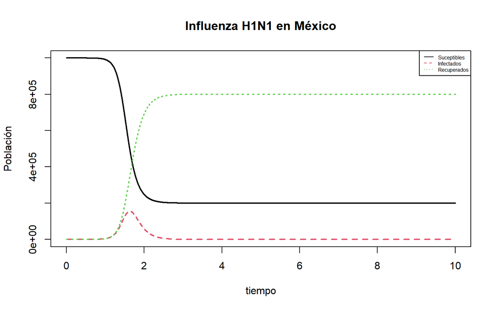

```r
### Funcion SIR:

SIR <- function(t, state, parameters) {
  with(as.list(c(state, parameters)), {

    dS <- -beta*S*I/(S+I+R)
    dI <- beta*S*I/(S+I+R) -gama*I
    dR <- gama*I

    list(c(dS, dI, dR))
  })
}

###  Condiciones iniciales:

pars_2 <- c(beta = 16.700000, gama = 8.300000)
condiciones_iniciales <- c(S = 10^6, I = 1, R = 0)
tiempo_2 <- seq(0, 10, by = 0.0001)
out_2 <- ode(condiciones_iniciales, tiempo_2, SIR, pars_2)


### Grafica:

matplot(out_2[ , 1], out_2[ , 2:4], type = "l", xlab = "tiempo", ylab = "Población", main = "Influenza H1N1 en México", lwd = 2)
legend("topright", c("Suceptibles", "Infectados","Recuperados"), col = 1:4, lty = 1:4, cex = 0.5)
```

$R_0 3 = 2.5$

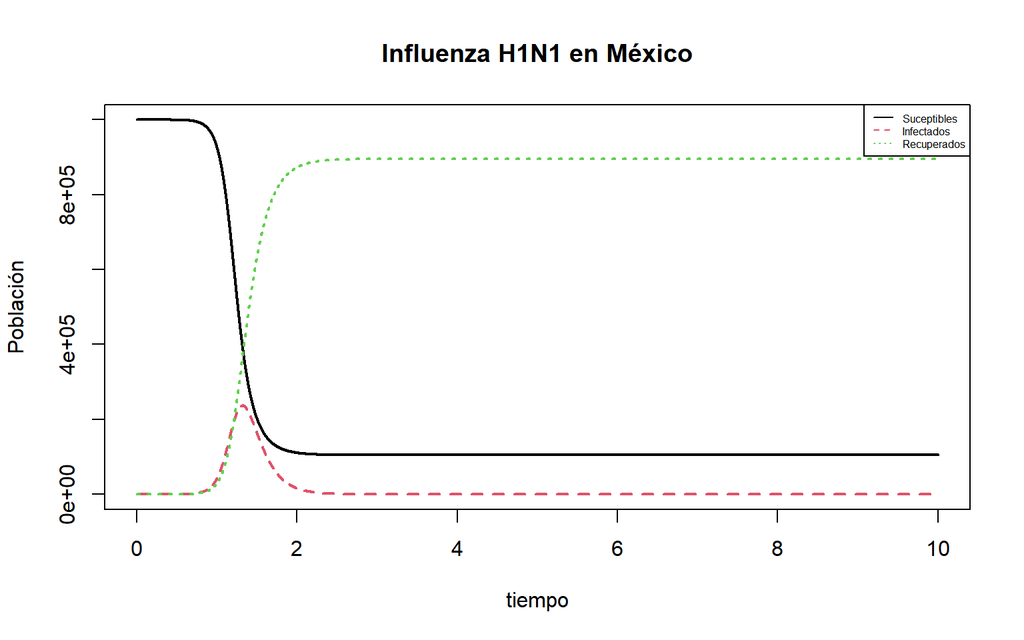

```r
### Funcion SIR:

SIR <- function(t, state, parameters) {
  with(as.list(c(state, parameters)), {

    dS <- -beta*S*I/(S+I+R)
    dI <- beta*S*I/(S+I+R) -gama*I
    dR <- gama*I

    list(c(dS, dI, dR))
  })
}

###  Condiciones iniciales:

pars_3 <- c(beta = 17.900000, gama = 7.100000)
condiciones_iniciales <- c(S = 10^6, I = 1, R = 0)
tiempo_3 <- seq(0, 10, by = 0.0001)
out_3 <- ode(condiciones_iniciales, tiempo_3, SIR, pars_3)


### Grafica:

matplot(out_3[ , 1], out_3[ , 2:4], type = "l", xlab = "tiempo", ylab = "Población", main = "Influenza H1N1 en México", lwd = 2)
legend("topright", c("Suceptibles", "Infectados","Recuperados"), col = 1:4, lty = 1:4, cex = 0.5)
```

## c) Considera los datos de la pandemia de H1N1 en México. Escoge valores de beta y gamma que den los valores de R0 de arriba pero que ajusten mejor los datos. Sugerencia utiliza un ciclo for para variar los valores.

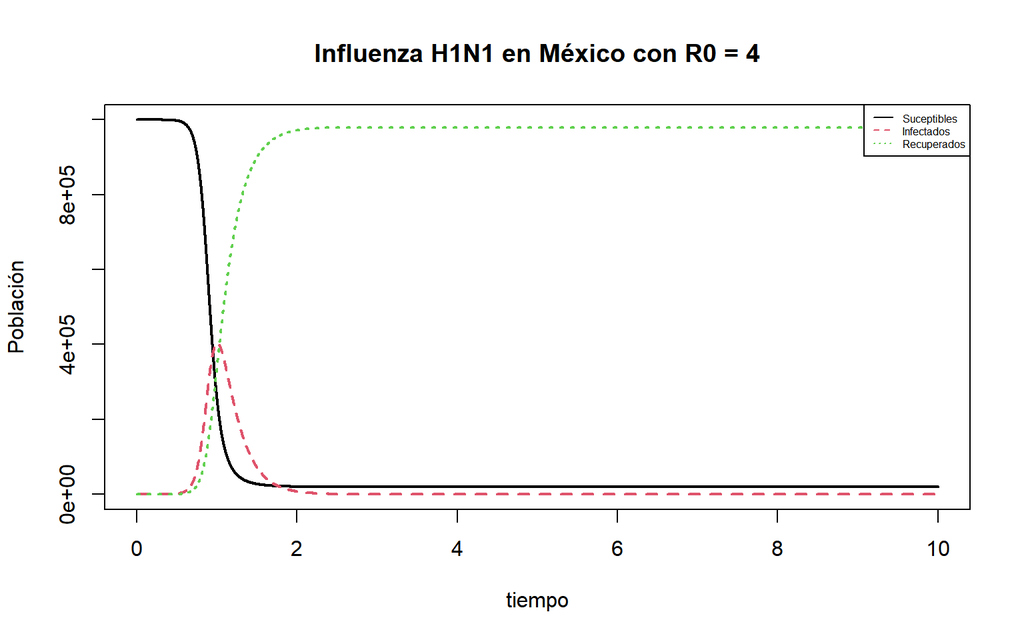

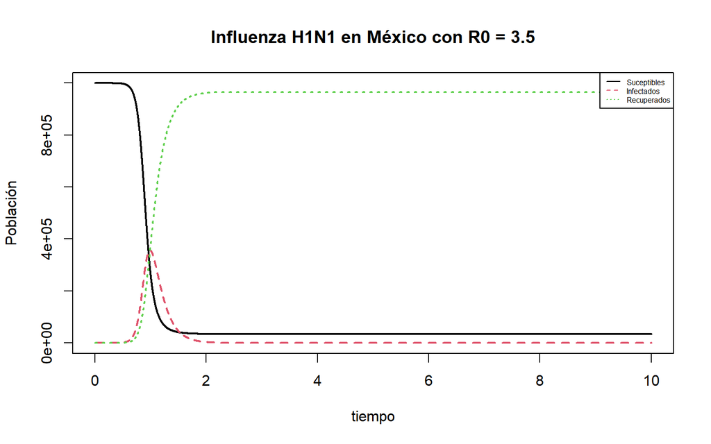

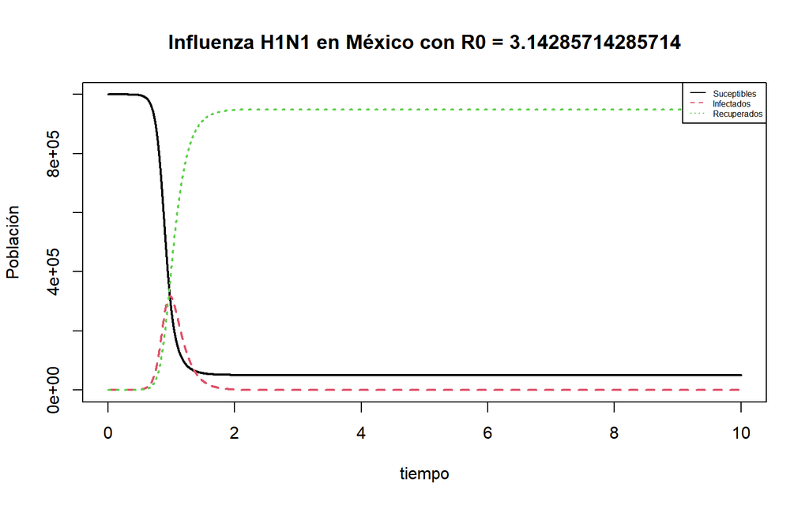

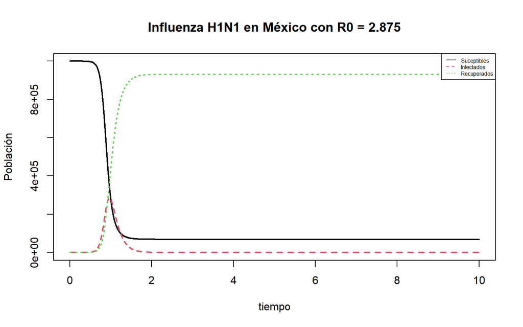

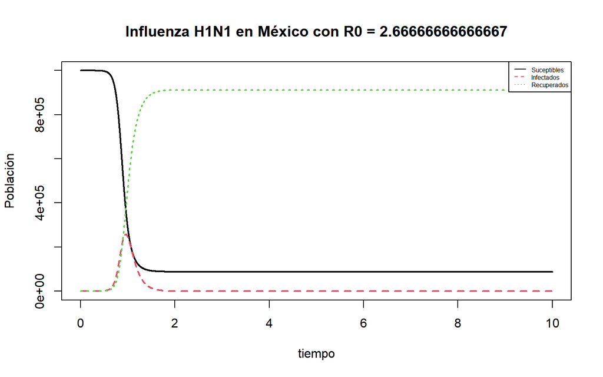

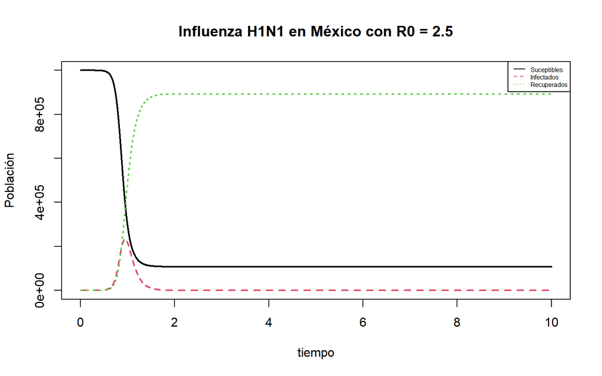

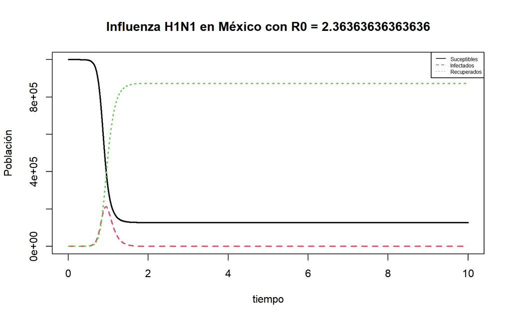

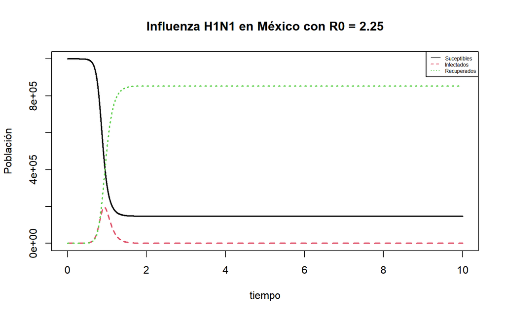

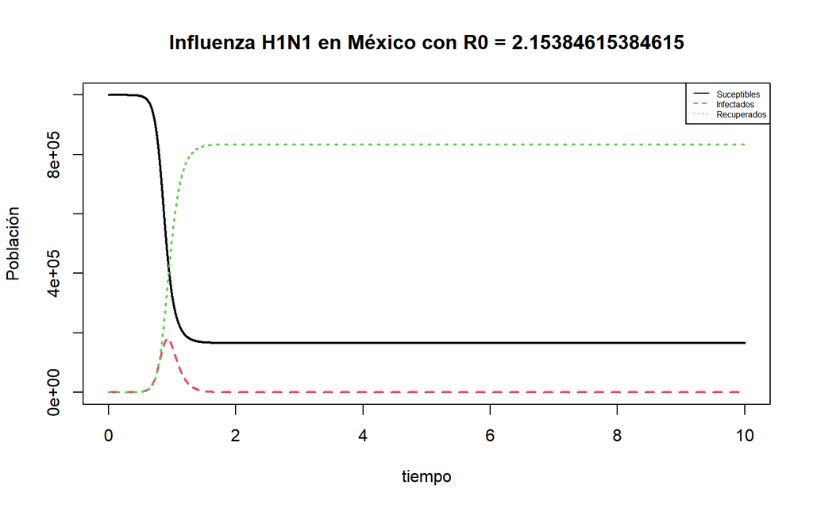

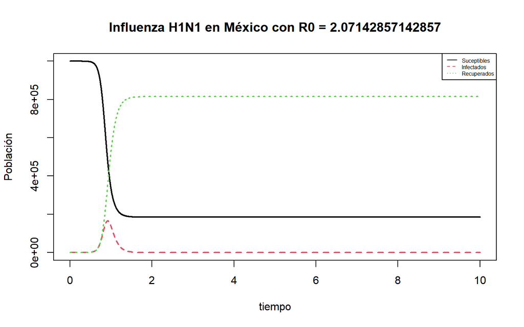

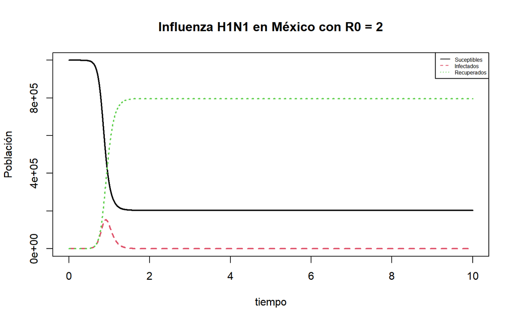

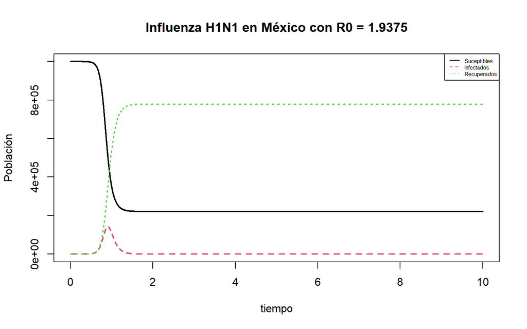

[9 more figures not shown]

```r
valores_beta <- 20:40

valores_gama <- 5:25


for (i in 1:length(valores_gama)) {

  beta <- valores_beta[i]
  gama <- valores_gama[i]


  SIR <- function(t, state, parameters) {
  with(as.list(c(state, parameters)), {

    dS <- -beta*S*I/(S+I+R)
    dI <- beta*S*I/(S+I+R) -gama*I
    dR <- gama*I

    list(c(dS, dI, dR))
  })
}

###  Condiciones iniciales:

pars <- c(beta = beta, gama = gama)
condiciones_iniciales <- c(S = 10^6, I = 1, R = 0)
tiempo <- seq(0, 10, by = 0.0001)
out <- ode(condiciones_iniciales, tiempo, SIR, pars)


### Grafica:

R0 <- beta/gama

matplot(out[ , 1], out[ , 2:4], type = "l", xlab = "tiempo", ylab = "Población", main = paste("Influenza H1N1 en México con R0 =", R0), lwd = 2)
legend("topright", c("Suceptibles", "Infectados","Recuperados"), col = 1:4, lty = 1:4, cex = 0.5)


}
```